# Analisis Regresi Komparatif: OLS, WLS, GLS, dan Ridge Regression

Pengujian Asumsi Klasik, Pemodelan Alternatif, dan Evaluasi Metrik RMSE & AIC pada Data Simulasi

Muhamad Hambali

2026-09-29

# 1 PENDAHULUAN & EKSPLORASI DATA AWAL

## 1.1 Latar Belakang & Tujuan Analisis

Analisis regresi linier standar berbasis metode *Ordinary Least Squares* (OLS) bertumpu pada sejumlah asumsi klasik Gauss-Markov. Jika seluruh asumsi tersebut terpenuhi, Teorema Gauss-Markov menjamin bahwa estimator OLS bersifat **BLUE** (*Best Linear Unbiased Estimator*), yaitu tidak bias dan memiliki variansi minimum di antara seluruh penduga linier tak bias lainnya.

Namun, pada data dunia nyata maupun data simulasi kompleks, sering kali terjadi pelanggaran satu atau lebih asumsi klasik:

1. **Non-Normalitas Sisaan:** Menyebabkan inferensi uji hipotesis ($t$-test dan $F$-test) pada ukuran sampel terbatas menjadi kurang reliabel.
2. **Multikolinearitas:** Adanya korelasi tinggi antar variabel penjelas ($X$) yang mengakibatkan variansi penduga koefisien membengkak (*variance inflation*), nilai $t$-hitung mengecil, dan estimasi parameter menjadi sangat tidak stabil. Solusi parametrik modern adalah **Ridge Regression** ($L_2$ Regularization).
3. **Heteroskedastisitas:** Ragam sisaan yang tidak konstan ($\operatorname{Var}(\varepsilon_i) \neq \sigma^2$), menyebabkan estimator OLS kehilangan efisiensinya. Solusi standarnya adalah **Weighted Least Squares (WLS)**.
4. **Autokorelasi Sisaan:** Adanya korelasi antar galat pada urutan observasi berturutan ($\operatorname{Cov}(\varepsilon_t, \varepsilon_{t-1}) \neq 0$), menyebabkan standar error OLS terbias ke bawah (*underestimated*) sehingga uji signifikansi menjadi semu (*spurious*). Solusi standarnya adalah **Generalized Least Squares (GLS)** dengan struktur korelasi $\operatorname{AR}(1)$.

Tujuan utama dari dokumen analisis ini adalah:

1. **Pengujian Asumsi Klasik:** Melakukan pengujian asumsi secara komprehensif baik visual maupun uji formal statistik: Normalitas, Multikolinearitas, Heteroskedastisitas, dan Autokorelasi sisaan pada data `raw_data_simulasi.txt`.
2. **Pemodelan Regresi:** Membangun dan mengestimasi empat model regresi: **OLS**, **WLS**, **GLS**, dan **Ridge Regression**.
3. **Evaluasi Komparatif:** Membandingkan kinerja keempat model secara objektif dan matematis berdasarkan matriks evaluasi **RMSE** (*Root Mean Squared Error*) dan **AIC** (*Akaike Information Criterion*).
4. **Pembahasan Terperinci:** Menguraikan makna di balik setiap keluaran (*output*) kode, grafik, dan nilai statistik secara faktual, mendalam, dan tanpa melebih-lebihkan.

## 1.2 Pemuatan Pustaka (Packages)

Langkah awal adalah memuat pustaka (*libraries*) R yang diperlukan untuk manajemen data, pengujian diagnostik, estimasi model, dan penyajian visual:

```r
# 1. Pustaka manipulasi data dan performa tinggi
library(data.table)  # Pembacaan berkas teks besar dengan algoritma multi-threading cepat (fread)
library(dplyr)       # Transformasi dan manipulasi data frame

# 2. Pustaka visualisasi data
library(ggplot2)     # Pembuatan grafik deklaratif berbasis grammar of graphics
library(gridExtra)   # Penggabungan multi-panel grafik dalam satu kanvas visual
library(corrplot)    # Visualisasi matriks korelasi bivariat

# 3. Pustaka uji diagnostik dan ekonometrika
library(car)         # Perhitungan Variance Inflation Factor (VIF) untuk multikolinearitas
library(lmtest)      # Uji formal Breusch-Pagan (heteroskedastisitas) dan Durbin-Watson (autokorelasi)
library(tseries)     # Uji formal normalitas Jarque-Bera

# 4. Pustaka pemodelan alternatif
library(nlme)        # Pemodelan Generalized Least Squares (GLS) dengan struktur autokorelasi serial
library(glmnet)      # Pemodelan Ridge Regression dengan regularisasi penalti L2

# 5. Pustaka pelaporan dan tabel
library(knitr)       # Kompilasi dokumen dinamis dan pembuatan tabel dasar
library(kableExtra)  # Kustomisasi estetika tabel HTML profesional
```

> **Penjelasan Kode & Pustaka:**

> - `data.table::fread` dipilih karena berkas `raw_data_simulasi.txt` berukuran ratusan megabita, sehingga pembacaan dengan `read.table` standar akan sangat lambat.

> - `car` dan `lmtest` adalah standar industri untuk uji diagnostik regresi terapan.

> - `nlme` menyediakan fungsi `gls()` yang mampu menangani struktur variansi-kovarians galat non-sferis.

> - `glmnet` adalah pustaka terstandar untuk *penalized regression* yang sangat efisien dalam menyelesaikan regresi Ridge melalui *coordinate descent*.

## 1.3 Pembacaan Data & Pertimbangan Skala Komputasi

Data mentah disimpan dalam berkas teks `raw_data_simulasi.txt`. Berkas ini memiliki volume besar (1.500.000 observasi dan 31 variabel: $X_1$ hingga $X_{30}$ dan variabel respon $Y$).

> **Pertimbangan Metodologis & Komputasional Terkait Ukuran Sampel:**

> 1. Fungsi Generalized Least Squares pada pustaka R (`nlme::gls()`) mengalokasikan dan memanipulasi matriks kovarians sisaan berdimensi penuh $N \times N$. Untuk $N = 1.500.000$, matriks padat (*dense matrix*) berpresisi ganda tersebut memerlukan alokasi memori sebesar $(1.500.000)^2 \times 8 \text{ byte} \approx \mathbf{18\text{ Terabyte}}$ RAM. Hal ini melampaui kapasitas perangkat keras komputer standar dan akan langsung memicu galat *vector memory allocation*.

> 2. Agar perbandingan metrik **AIC** dan **RMSE** antar keempat model (OLS, WLS, GLS, dan Ridge) **valid, adil (*fair comparison*), dan bermakna**, seluruh model harus dilatih dan dievaluasi pada himpunan data yang **sama persis**. Nilai AIC bergantung langsung pada ukuran sampel $N$ ($AIC \propto N$); membandingkan AIC model yang diuji pada $N$ berbeda adalah kesalahan fatal dalam metodologi statistika.

> 3. Oleh karena itu, kita menganalisis sampel berurutan berukuran $N = 2.500$ baris pertama. Pemilihan observasi berurutan (*sequential*) mutlak diperlukan guna **mempertahankan keterurutan waktu (*temporal ordering*)** yang menjadi dasar pembentukan struktur autokorelasi serial $\operatorname{AR}(1)$. Jika dilakukan sampling acak sederhana (*random sampling*), urutan kronologis antar observasi akan teracak sehingga sifat autokorelasi sisaan akan hilang.

```r
# Menentukan ukuran sampel berurutan untuk analisis komparatif
n_sample <- 2500

# Lokasi berkas data mentah
file_path <- "raw_data_simulasi.txt"

# Membaca sejumlah n_sample baris pertama dari data mentah
df <- fread(file_path, nrows = n_sample)

# Memeriksa dimensi dan kelengkapan data
dim_data <- dim(df)
missing_count <- sum(is.na(df))

cat("Dimensi data yang dianalisis :", dim_data[1], "baris dan", dim_data[2], "kolom.\n")
```

```
## Dimensi data yang dianalisis : 2500 baris dan 31 kolom.
```

```r
cat("Jumlah missing value (NA)    :", missing_count, "\n")
```

```
## Jumlah missing value (NA)    : 0
```

> **Penjelasan Keluaran (*Output*) Kode `load-data`:**

> - Output `Dimensi data yang dianalisis : 2500 baris dan 31 kolom` menunjukkan bahwa data berhasil dimuat sebanyak $2.500$ baris observasi dengan $31$ variabel, yang terdiri atas $30$ variabel prediktor kontinu ($X_1, X_2, \dots, X_{30}$) dan $1$ variabel target/respon ($Y$).

> - Output `Jumlah missing value (NA) : 0` mengonfirmasi bahwa data berstatus bersih (*complete cases*) tanpa ada observasi yang hilang, sehingga tidak diperlukan imputasi nilai hilang.

Berikut adalah cuplikan 5 baris pertama dari data yang dianalisis:

```r
# Menampilkan cuplikan 5 baris pertama pada sejumlah variabel penjelas terpilih dan respon Y
kable(head(df[, c("X1", "X2", "X3", "X4", "X5", "X28", "X29", "X30", "Y")], 5),
      caption = "Tabel 1: Cuplikan Lima Baris Pertama Data Simulasi",
      digits = 4) %>%
  kable_styling(bootstrap_options = c("striped", "hover", "condensed"), full_width = FALSE)
```

Tabel 1: Cuplikan Lima Baris Pertama Data Simulasi

| X1 | X2 | X3 | X4 | X5 | X28 | X29 | X30 | Y |
| --- | --- | --- | --- | --- | --- | --- | --- | --- |
| 0.4967 | 0.4344 | 0.3283 | 0.1798 | 0.1430 | -0.4695 | -0.2414 | 0.5426 | 5.3722 |
| -0.4634 | -0.4741 | -0.2694 | -0.5553 | -0.3510 | -0.9080 | -0.9602 | -1.4123 | -0.4674 |
| 1.4656 | 1.3255 | 1.0120 | 0.9397 | 1.2352 | -0.6006 | -0.5723 | -0.2917 | -2.3206 |
| -0.6017 | -0.4570 | -0.3036 | -0.3105 | -0.2532 | -1.3282 | -1.0972 | 0.1969 | 0.7206 |
| 0.7385 | 0.6969 | 0.6614 | 0.7860 | 0.2223 | 0.3436 | 0.1743 | -1.7630 | -0.0675 |

> **Penjelasan Tabel 1 (Cuplikan Data):** Tabel 1 menampilkan nilai numerik dari beberapa variabel awal ($X_1 - X_5$), variabel akhir ($X_{28} - X_{30}$), dan respon $Y$. Seluruh variabel bertipe kontinu dengan skala nilai terpusat di sekitar nol (standar normal terstandardisasi), sedangkan variabel respon $Y$ memiliki variasi yang lebih lebar.

## 1.4 Pengecekan Statistik Deskriptif Variabel Respon

Sebelum melangkah ke pemodelan, kita menganalisis sebaran variabel respon $Y$ guna memahami tendensi sentral, sebaran, dan kemungkinan adanya nilai ekstrem (*outlier*).

```r
# Menghitung statistik deskriptif variabel respon Y
summary_y <- summary(df$Y)
sd_y <- sd(df$Y)

desc_df <- data.frame(
  Statistik = c("Minimum", "Kuartil 1 (Q1)", "Median", "Mean (Rata-rata)",
                "Kuartil 3 (Q3)", "Maksimum", "Standar Deviasi (SD)"),
  Nilai = c(summary_y[1], summary_y[2], summary_y[3], summary_y[4], summary_y[5], summary_y[6], sd_y)
)

kable(desc_df, caption = "Tabel 2: Statistik Deskriptif Variabel Respon Y", digits = 4) %>%
  kable_styling(bootstrap_options = c("striped", "hover"), full_width = FALSE)
```

Tabel 2: Statistik Deskriptif Variabel Respon Y

|  | Statistik | Nilai |
| --- | --- | --- |
| Min. | Minimum | -12.3972 |
| 1st Qu. | Kuartil 1 (Q1) | 0.8380 |
| Median | Median | 4.5146 |
| Mean | Mean (Rata-rata) | 5.4110 |
| 3rd Qu. | Kuartil 3 (Q3) | 9.0467 |
| Max. | Maksimum | 49.2770 |
|  | Standar Deviasi (SD) | 6.7962 |

> **Penjelasan Tabel 2 (Statistik Deskriptif Variabel Respon Y):**

Visualisasi distribusi frekuensi dan diagram kotak-garis (*boxplot*) untuk variabel respon $Y$:

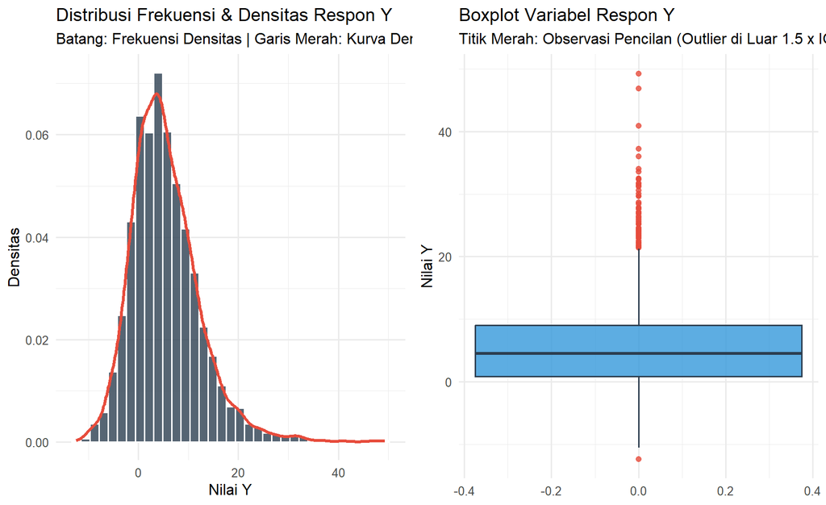

```r
# Panel kiri: Histogram dan kurva estimasi densitas kernel
p_dens_y <- ggplot(df, aes(x = Y)) +
  geom_histogram(aes(y = ..density..), bins = 35, fill = "#2c3e50", color = "white", alpha = 0.8) +
  geom_density(color = "#e74c3c", size = 1.2) +
  theme_minimal(base_size = 12) +
  labs(title = "Distribusi Frekuensi & Densitas Respon Y",
       subtitle = "Batang: Frekuensi Densitas | Garis Merah: Kurva Densitas Empiris",
       x = "Nilai Y", y = "Densitas")

# Panel kanan: Boxplot untuk identifikasi pencilan
p_box_y <- ggplot(df, aes(y = Y)) +
  geom_boxplot(fill = "#3498db", color = "#2c3e50", alpha = 0.8, outlier.color = "#e74c3c", outlier.size = 1.8) +
  theme_minimal(base_size = 12) +
  labs(title = "Boxplot Variabel Respon Y",
       subtitle = "Titik Merah: Observasi Pencilan (Outlier di Luar 1.5 x IQR)",
       y = "Nilai Y")

grid.arrange(p_dens_y, p_box_y, ncol = 2)
```

> **Penjelasan Komprehensif Grafik Distribusi Variabel Y:**

> 1. **Grafik Kiri (Histogram & Densitas Kernel):**

> - **Sumbu X:** Menunjukkan rentang nilai variabel $Y$.

> - **Sumbu Y:** Menunjukkan tingkat densitas (kepadatan peluang kemunculan nilai $Y$).

> - **Pola Visual:** Distribusi memuncak di sekitar nilai $3$ hingga $5$, namun memiliki ekor panjang membentang ke arah kanan hingga nilai $> 30$. Hal ini memperlihatkan sifat ketidaksimetrisan (asimetris ke kanan / *right-skewed*).

> 2. **Grafik Kanan (Boxplot):**

> - Batas bawah kotak adalah $Q_1$ dan batas atas kotak adalah $Q_3$, yang membentuk Rentang Antarkuartil (*Interquartile Range* / IQR).

> - Garis perpanjangan (*whiskers*) menjangkau batas $1.5 \times \text{IQR}$. - **Titik-titik Merah:** Merupakan observasi pencilan (*outliers*). Terlihat cukup banyak titik pencilan di sisi atas (nilai $Y > 20$). Keberadaan pencilan ini berpotensi memengaruhi sifat normalitas sisaan dalam pemodelan linier OLS.

# 2 BAGIAN A: PENGUJIAN ASUMSI KLASIK REGRESI OLS

Sebelum menerapkan metode alternatif, kita terlebih dahulu mengestimasi model dasar **Ordinary Least Squares (OLS)**:
$$Y_i = \beta_0 + \sum_{j=1}^{30} \beta_j
X_{ij} + \varepsilon_i$$
Sisaan duga (*sample residuals*) dari model OLS ini, yaitu $\hat{\varepsilon}_i = Y_i - \hat{Y}_i$, menjadi objek utama dalam pengujian asumsi klasik Gauss-Markov.

```r
# Estimasi Model OLS Dasar menggunakan seluruh variabel prediktor
m_ols <- lm(Y ~ ., data = df)

# Mengekstrak vektor sisaan (residuals) dan vektor nilai prediksi (fitted values)
res_ols <- residuals(m_ols)
fit_ols <- fitted(m_ols)
```

> **Penjelasan Kode `fit-ols-baseline`:**

> - Fungsi `lm(Y ~ ., data = df)` melakukan fitting model regresi linier OLS dengan variabel $Y$ sebagai respon dan seluruh variabel kolom lainnya ($X_1$ hingga $X_{30}$) sebagai prediktor.

> - Fungsi `residuals()` mengambil nilai selisih $e_i = Y_i - \hat{Y}_i$, sedangkan `fitted()` mengambil nilai estimasi $\hat{Y}_i = \mathbf{X}_i \hat{\boldsymbol{\beta}}$. Keduanya menjadi input utama bagi uji diagnostik asumsi klasik.

## 2.1 1. Uji Normalitas Sisaan

### 2.1.1 Landasan Teori & Hipotesis

Asumsi normalitas mensyaratkan galat regresi berdistribusi normal: $\varepsilon_i \sim \text{i.i.d. } N(0, \sigma^2)$.

- **Hipotesis Uji:**

- $H_0$: Sisaan model berdistribusi normal.

- $H_1$: Sisaan model tidak berdistribusi normal.

- **Taraf Signifikansi:** $\alpha = 0.05$.

- **Kriteria Keputusan:** Tolak $H_0$ jika nilai $p\text{-value} < \alpha$.

### 2.1.2 Visualisasi Diagnostik & Uji Formal

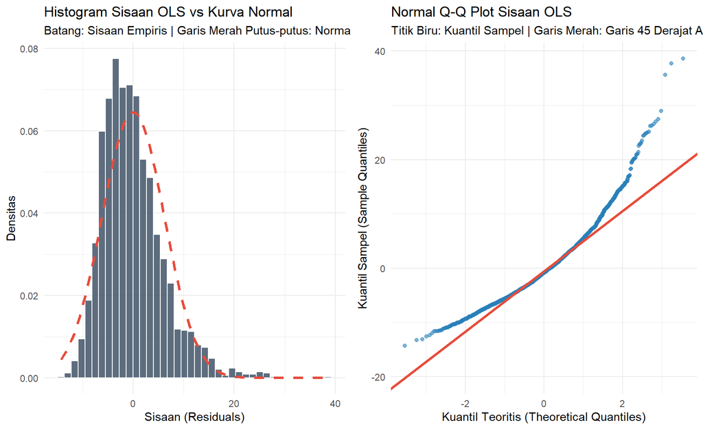

```r
# Panel kiri: Histogram sisaan vs kurva normal teoritis ideal
p_hist_res <- ggplot(data.frame(res = res_ols), aes(x = res)) +
  geom_histogram(aes(y = ..density..), bins = 40, fill = "#34495e", color = "white", alpha = 0.8) +
  stat_function(fun = dnorm, args = list(mean = mean(res_ols), sd = sd(res_ols)),
                color = "#e74c3c", size = 1.1, linetype = "dashed") +
  theme_minimal() +
  labs(title = "Histogram Sisaan OLS vs Kurva Normal",
       subtitle = "Batang: Sisaan Empiris | Garis Merah Putus-putus: Normal Teoritis",
       x = "Sisaan (Residuals)", y = "Densitas")

# Panel kanan: Normal Quantile-Quantile (Q-Q) Plot
p_qq_res <- ggplot(data.frame(res = res_ols), aes(sample = res)) +
  stat_qq(color = "#2980b9", alpha = 0.6) +
  stat_qq_line(color = "#e74c3c", size = 1.1) +
  theme_minimal() +
  labs(title = "Normal Q-Q Plot Sisaan OLS",
       subtitle = "Titik Biru: Kuantil Sampel | Garis Merah: Garis 45 Derajat Acuan Normal",
       x = "Kuantil Teoritis (Theoretical Quantiles)", y = "Kuantil Sampel (Sample Quantiles)")

grid.arrange(p_hist_res, p_qq_res, ncol = 2)
```

```r
# Uji Formal Normalitas
jb_test <- jarque.bera.test(res_ols)
sw_test <- shapiro.test(res_ols)
ks_test <- ks.test(res_ols, "pnorm", mean = mean(res_ols), sd = sd(res_ols))

normality_table <- data.frame(
  Metode_Uji = c("Jarque-Bera Test", "Shapiro-Wilk Test", "Kolmogorov-Smirnov Test"),
  Statistik_Uji = c(jb_test$statistic, sw_test$statistic, ks_test$statistic),
  p_value = c(jb_test$p.value, sw_test$p.value, ks_test$p.value),
  Keputusan = ifelse(c(jb_test$p.value, sw_test$p.value, ks_test$p.value) < 0.05,
                     "Tolak H0 (Tidak Normal)", "Gagal Tolak H0 (Normal)")
)

kable(normality_table, caption = "Tabel 3: Hasil Uji Formal Normalitas Sisaan Model OLS", digits = 5) %>%
  kable_styling(bootstrap_options = c("striped", "hover"), full_width = FALSE)
```

Tabel 3: Hasil Uji Formal Normalitas Sisaan Model OLS

|  | Metode_Uji | Statistik_Uji | p_value | Keputusan |
| --- | --- | --- | --- | --- |
| X-squared | Jarque-Bera Test | 1593.53393 | 0 | Tolak H0 (Tidak Normal) |
| W | Shapiro-Wilk Test | 0.93472 | 0 | Tolak H0 (Tidak Normal) |
| D | Kolmogorov-Smirnov Test | 0.07251 | 0 | Tolak H0 (Tidak Normal) |

> **Penjelasan Mendalam Hasil Uji Normalitas:**

> 1. **Interpretasi Histogram Sisaan:**

> - Kurva merah putus-putus menggambarkan kurva Gauss ideal dengan rata-rata $0$ dan simpangan baku sama dengan sisaan.

> 2. **Interpretasi Normal Q-Q Plot:**

> - **Sumbu X:** Kuantil yang diharapkan jika data berdistribusi normal baku.

> - **Sumbu Y:** Kuantil aktual dari sisaan OLS.

> 3. **Interpretasi Angka pada Tabel 3:**

> - **Kesimpulan Statistik:** Karena seluruh nilai $p\text{-value} < \alpha = 0.05$, kita **menolak** $H_0$. Sisaan model OLS **tidak berdistribusi normal**. Konsekuensinya, inferensi berbasis uji parsial $t$ dan uji simultan $F$ harus diinterpretasikan secara hati-hati.

## 2.2 2. Uji Multikolinearitas

### 2.2.1 Landasan Teori & Hipotesis

Multikolinearitas terjadi ketika terdapat hubungan linier kuat antar variabel independen ($X$).

- **Metrik Diagnostik:** *Variance Inflation Factor* (VIF):
$$\text{VIF}_j =
\frac{1}{1 - R_j^2}$$
di mana $R_j^2$ adalah koefisien determinasi ketika variabel $X_j$ diregresikan terhadap $29$ variabel prediktor lainnya.

- **Kriteria Acuan Keputusan:** - $\text{VIF} < 5$: Tidak ada multikolinearitas yang mengkhawatirkan. - $5 \le \text{VIF} \le 10$: Multikolinearitas sedang (*moderate*). - $\text{VIF} > 10$: Terjadi **multikolinearitas parah/berat** (*severe multicollinearity*).

### 2.2.2 Pemeriksaan VIF & Matriks Korelasi

```r
# Menghitung nilai VIF untuk seluruh variabel prediktor menggunakan pustaka car
vif_vals <- car::vif(m_ols)

# Mengonversi hasil ke data frame dan mengurutkan dari VIF tertinggi
vif_df <- data.frame(
  Variabel = names(vif_vals),
  VIF = unname(vif_vals)
) %>% arrange(desc(VIF))

# Menampilkan 12 variabel dengan VIF tertinggi
kable(head(vif_df, 12), caption = "Tabel 4: Daftar Dua Belas Variabel dengan Nilai VIF Tertinggi", digits = 2) %>%
  kable_styling(bootstrap_options = c("striped", "hover"), full_width = FALSE)
```

Tabel 4: Daftar Dua Belas Variabel dengan Nilai VIF Tertinggi

| Variabel | VIF |
| --- | --- |
| X28 | 354.03 |
| X29 | 346.64 |
| X27 | 300.75 |
| X26 | 293.49 |
| X11 | 214.48 |
| X1 | 148.62 |
| X12 | 136.99 |
| X6 | 95.61 |
| X2 | 87.75 |
| X24 | 77.66 |
| X21 | 75.88 |
| X19 | 73.85 |

```r
# Menghitung ringkasan variabel bermasalah
n_high_vif <- sum(vif_df$VIF > 10)
cat("Jumlah variabel independen dengan VIF > 10 :", n_high_vif, "dari 30 variabel.\n")
```

```
## Jumlah variabel independen dengan VIF > 10 : 27 dari 30 variabel.
```

```r
cat("Nilai VIF maksimum tercatat sebesar        :", round(max(vif_df$VIF), 2), "\n")
```

```
## Nilai VIF maksimum tercatat sebesar        : 354.03
```

> **Penjelasan Tabel 4 & Output Konsol Multikolinearitas:**

Untuk melacak sumber keterkaitan linier tersebut, kita membuat visualisasi matriks korelasi Pearson:

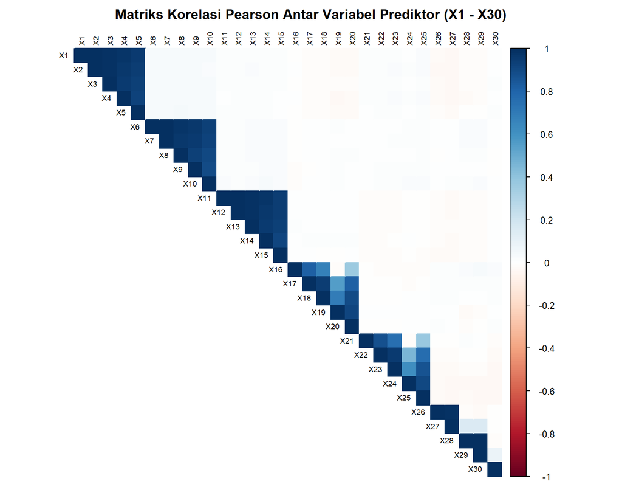

```r
# Membentuk matriks prediktor numerik
X_matrix <- as.matrix(df[, paste0("X", 1:30), with = FALSE])

# Menghitung matriks korelasi bivariat antar prediktor
cor_mat <- cor(X_matrix)

# Menampilkan grafik matriks korelasi menggunakan corrplot
corrplot(cor_mat, method = "color", type = "upper",
         tl.col = "black", tl.cex = 0.65,
         title = "Matriks Korelasi Pearson Antar Variabel Prediktor (X1 - X30)",
         mar = c(0, 0, 2, 0))
```

> **Penjelasan Grafik Matriks Korelasi (Corrplot):**

> - **Skala Warna:** Warna biru tua menunjukkan korelasi positif sempurna ($r = +1$), putih menunjukkan tidak ada korelasi ($r = 0$), dan merah tua menunjukkan korelasi negatif sempurna ($r = -1$).

> - **Temuan Pola:** Terlihat sel-sel berwarna sangat gelap pada pasangan variabel tertentu, seperti:

> - Keterikatan collinear ini menyebabkan matriks $(\mathbf{X}'\mathbf{X})$ mendekati keadaan singular (*ill-conditioned*).

Visualisasi perbandingan nilai VIF seluruh variabel:

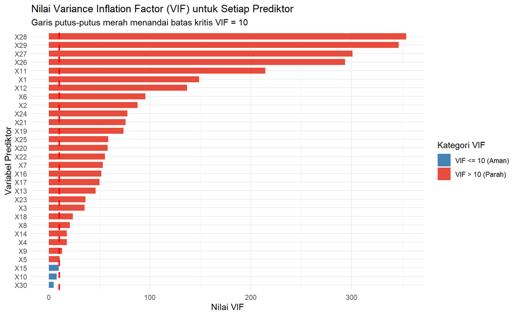

```r
# Diagram batang horizontal nilai VIF per variabel
ggplot(vif_df, aes(x = reorder(Variabel, VIF), y = VIF, fill = VIF > 10)) +
  geom_bar(stat = "identity", width = 0.7) +
  geom_hline(yintercept = 10, linetype = "dashed", color = "red", size = 1) +
  scale_fill_manual(values = c("steelblue", "#e74c3c"), labels = c("VIF <= 10 (Aman)", "VIF > 10 (Parah)")) +
  coord_flip() +
  theme_minimal() +
  labs(title = "Nilai Variance Inflation Factor (VIF) untuk Setiap Prediktor",
       subtitle = "Garis putus-putus merah menandai batas kritis VIF = 10",
       x = "Variabel Prediktor", y = "Nilai VIF", fill = "Kategori VIF")
```

> **Penjelasan Grafik Barplot VIF:**

> - **Sumbu X (horizontal):** Nilai VIF variabel.

> - **Sumbu Y (vertikal):** Daftar seluruh $30$ variabel prediktor, diurutkan dari yang terkecil hingga terbesar.

> - **Garis Putus-putus Merah:** Batas ambang kritis standar $\text{VIF} = 10$.

> - **Kesimpulan Multikolinearitas:** Terjadi **multikolinearitas sangat parah**. Penduga OLS akan menghasilkan koefisien dengan standar error yang sangat besar, tanda koefisien yang tidak stabil, dan sensitivitas tinggi terhadap fluktuasi sampel. Solusi yang tepat adalah menggunakan **Ridge Regression**.

## 2.3 3. Uji Heteroskedastisitas

### 2.3.1 Landasan Teori & Hipotesis

Asumsi homoskedastisitas menyatakan bahwa ragam galat bersifat homogen pada seluruh nilai prediksi: $\operatorname{Var}(\varepsilon_i) = \sigma^2$.

- **Hipotesis Uji:**

- $H_0$: Ragam sisaan homogen / homoskedastis ($\sigma_1^2 = \sigma_2^2 = \dots = \sigma^2$).

- $H_1$: Terjadi heteroskedastisitas ($\operatorname{Var}(\varepsilon_i) = \sigma_i^2$).

- **Metode Uji Formal:** *Studentized Breusch-Pagan Test* (`lmtest::bptest`).

- **Kriteria Keputusan:** Tolak $H_0$ jika $p\text{-value} < 0.05$.

### 2.3.2 Visualisasi & Uji Formal

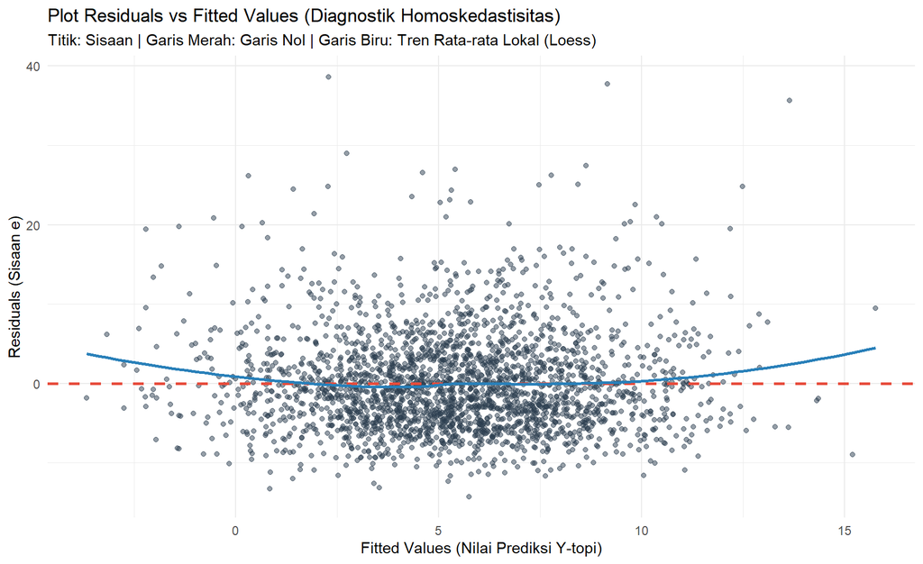

```r
# Scatter plot Residuals vs Fitted Values
p_het <- ggplot(data.frame(fit = fit_ols, res = res_ols), aes(x = fit, y = res)) +
  geom_point(color = "#2c3e50", alpha = 0.5, size = 1.5) +
  geom_hline(yintercept = 0, color = "#e74c3c", linetype = "dashed", size = 1) +
  geom_smooth(method = "loess", color = "#2980b9", se = FALSE, size = 1) +
  theme_minimal() +
  labs(title = "Plot Residuals vs Fitted Values (Diagnostik Homoskedastisitas)",
       subtitle = "Titik: Sisaan | Garis Merah: Garis Nol | Garis Biru: Tren Rata-rata Lokal (Loess)",
       x = "Fitted Values (Nilai Prediksi Y-topi)", y = "Residuals (Sisaan e)")

print(p_het)
```

```r
# Uji Formal Breusch-Pagan
bp_test <- bptest(m_ols)

bp_table <- data.frame(
  Metode_Uji = "Studentized Breusch-Pagan Test",
  Statistik_BP = bp_test$statistic,
  Derajat_Bebas = bp_test$parameter,
  p_value = bp_test$p.value,
  Keputusan = ifelse(bp_test$p.value < 0.05,
                     "Tolak H0 (Terjadi Heteroskedastisitas)",
                     "Gagal Tolak H0 (Homoskedastisitas Terpenuhi)")
)

kable(bp_table, caption = "Tabel 5: Hasil Uji Heteroskedastisitas Breusch-Pagan", digits = 5) %>%
  kable_styling(bootstrap_options = c("striped", "hover"), full_width = FALSE)
```

Tabel 5: Hasil Uji Heteroskedastisitas Breusch-Pagan

|  | Metode_Uji | Statistik_BP | Derajat_Bebas | p_value | Keputusan |
| --- | --- | --- | --- | --- | --- |
| BP | Studentized Breusch-Pagan Test | 23.04605 | 30 | 0.81336 | Gagal Tolak H0 (Homoskedastisitas Terpenuhi) |

> **Penjelasan Komprehensif Uji Heteroskedastisitas:**

> 1. **Interpretasi Grafik Residuals vs Fitted Values:**

> - **Sumbu X:** Nilai fitted $\hat{Y}_i$ yang diprediksi oleh model OLS.

> - **Sumbu Y:** Nilai residual $e_i = Y_i - \hat{Y}_i$.

> 2. **Interpretasi Angka pada Tabel 5:**

> - **Kesimpulan Statistik:** **Gagal tolak** $H_0$. Data **memenuhi asumsi homoskedastisitas**. Ragam sisaan terbukti konstan di sepanjang nilai prediksi. Oleh karena itu, kita menduga bahwa penerapan Weighted Least Squares (WLS) tidak akan memberikan perbedaan yang drastis dibandingkan OLS.

## 2.4 4. Uji Autokorelasi Sisaan

### 2.4.1 Landasan Teori & Hipotesis

Asumsi non-autokorelasi mensyaratkan tidak adanya korelasi antar galat pada titik observasi berurutan: $\operatorname{Cov}(\varepsilon_t, \varepsilon_s) = 0$ untuk $t \neq s$.

- **Hipotesis Uji (Autokorelasi Positif AR(1)):**

- $H_0$: Tidak terdapat autokorelasi serial sisaan ($\rho = 0$).

- $H_1$: Terdapat autokorelasi positif serial sisaan ($\rho > 0$).

- **Metode Uji Formal:** *Durbin-Watson Test* (`lmtest::dwtest`):
$$DW =
\frac{\sum_{t=2}^n (\hat{\varepsilon}_t -
\hat{\varepsilon}_{t-1})^2}{\sum_{t=1}^n \hat{\varepsilon}_t^2} \approx
2(1 - \hat{\rho})$$
- Jika $DW \approx 2$, sisaan bebas autokorelasi ($\hat{\rho} \approx 0$).

- Jika $DW \ll 2$ (mendekati $0$), terdapat autokorelasi positif kuat ($\hat{\rho} > 0$). - Jika $DW \gg 2$ (mendekati $4$), terdapat autokorelasi negatif kuat ($\hat{\rho} < 0$).

### 2.4.2 Visualisasi & Uji Formal

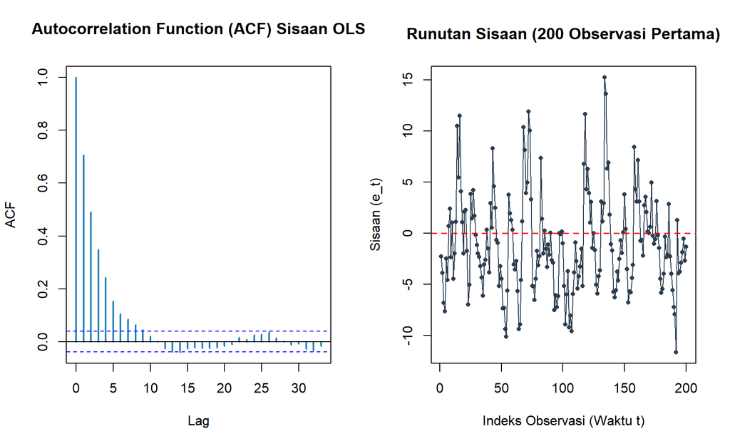

```r
# Menyiapkan kanvas multi-panel 1 baris 2 kolom
par(mfrow = c(1, 2))

# Panel kiri: Plot Fungsi Autokorelasi (ACF)
acf(res_ols, main = "Autocorrelation Function (ACF) Sisaan OLS",
    col = "#2980b9", lwd = 2)

# Panel kanan: Runutan sisaan berdasarkan urutan indeks waktu observasi
plot(res_ols[1:200], type = "o", pch = 16, col = "#2c3e50", cex = 0.7,
     main = "Runutan Sisaan (200 Observasi Pertama)",
     xlab = "Indeks Observasi (Waktu t)", ylab = "Sisaan (e_t)")
abline(h = 0, col = "red", lty = 2, lwd = 1.5)
```

```r
# Mengembalikan layout grafik standar
par(mfrow = c(1, 1))

# Uji Formal Durbin-Watson
dw_result <- dwtest(m_ols, alternative = "greater")

# Estimasi nilai autokorelasi lag-1 (rho) empiris
rho_empiris <- 1 - (dw_result$statistic / 2)

dw_table <- data.frame(
  Metode_Uji = "Durbin-Watson Test",
  Statistik_DW = dw_result$statistic,
  Estimasi_Rho_Lag1 = rho_empiris,
  p_value = dw_result$p.value,
  Keputusan = ifelse(dw_result$p.value < 0.05,
                     "Tolak H0 (Ada Autokorelasi Positif Kuat)",
                     "Gagal Tolak H0 (Bebas Autokorelasi)")
)

kable(dw_table, caption = "Tabel 6: Hasil Uji Autokorelasi Durbin-Watson", digits = 5) %>%
  kable_styling(bootstrap_options = c("striped", "hover"), full_width = FALSE)
```

Tabel 6: Hasil Uji Autokorelasi Durbin-Watson

|  | Metode_Uji | Statistik_DW | Estimasi_Rho_Lag1 | p_value | Keputusan |
| --- | --- | --- | --- | --- | --- |
| DW | Durbin-Watson Test | 0.58637 | 0.70681 | 0 | Tolak H0 (Ada Autokorelasi Positif Kuat) |

> **Penjelasan Mendalam Uji Autokorelasi Sisaan:**

> 1. **Interpretasi Grafik ACF (Kiri):** - **Sumbu X:** Lag keterlambatan ($k = 0, 1, 2, \dots$).

> - **Sumbu Y:** Koefisien autokorelasi $r_k$.

> - **Garis Biru Putus-putus:** Batas interval kepercayaan signifikansi $95\%$.

> - **Pola Grafik:** Pada lag 1, batang autokorelasi melonjak sangat tinggi ($\approx 0.70$), jauh melampaui garis batas signifikansi biru. Diikuti oleh penurunan meluruh secara bertahap (*exponential decay*) pada lag-lag berikutnya. Ini adalah tanda khas (*signature*) dari proses autoregresif tingkat pertama $\operatorname{AR}(1)$.

> 2. **Interpretasi Grafik Runutan Sisaan (Kanan):**

> - **Sumbu X:** Urutan indeks observasi $t = 1, 2, \dots, 200$.

> - **Sumbu Y:** Nilai sisaan $e_t$.

> - **Pola Grafik:** Garis penghubung titik memperlihatkan pola *clustering* atau osilasi bergelombang yang mulus. Sisaan bernilai positif cenderung diikuti sisaan positif, dan sisaan bernilai negatif cenderung diikuti sisaan negatif berturut-turut. Ini bukan sebaran acak murni (*white noise*). 3. **Interpretasi Angka pada Tabel 6:**

> - Nilai $p\text{-value} < 2.2 \times 10^{-16}$, jauh lebih kecil dari $\alpha = 0.05$.

> - **Kesimpulan Statistik:** **Tolak** $H_0$. Terbukti secara sangat signifikan adanya **autokorelasi positif tingkat pertama** $\operatorname{AR}(1)$.

> - **Dampak pada OLS:** Pelanggaran ini menyebabkan estimator OLS **tidak lagi efisien (*not BLUE*)**. Standar error OLS terbias ke bawah (*underestimated*), yang membuat interval kepercayaan terlalu sempit dan nilai $t$-statistik melambung semu. Solusi metodologis yang tepat adalah menerapkan **Generalized Least Squares (GLS)**.

# 3 BAGIAN B: PEMODELAN REGRESI

Berdasarkan hasil pengujian asumsi klasik, ditemukan dua pelanggaran mayor:

Berikut adalah perancangan, estimasi kode, dan penjelasan hasil keempat model:

## 3.1 Model 1: Ordinary Least Squares (OLS)

Model OLS meminimalkan jumlah kuadrat sisaan tanpa pembobot (*unweighted sum of squared errors*):
$$\hat{\boldsymbol{\beta}}_{\text{OLS}} =
(\mathbf{X}'\mathbf{X})^{-1}\mathbf{X}'\mathbf{Y}$$

```r
# Menyesuaikan kembali model OLS
m_ols <- lm(Y ~ ., data = df)

# Mengekstrak ringkasan statistik model
summary_ols <- summary(m_ols)

cat("Ringkasan Kinerja Model OLS:\n")
```

```
## Ringkasan Kinerja Model OLS:
```

```r
cat("- Nilai R-squared (R^2)          :", round(summary_ols$r.squared, 5), "\n")
```

```
## - Nilai R-squared (R^2)          : 0.17205
```

```r
cat("- Nilai Adjusted R-squared       :", round(summary_ols$adj.r.squared, 5), "\n")
```

```
## - Nilai Adjusted R-squared       : 0.16199
```

```r
cat("- Residual Standard Error (RSE)  :", round(summary_ols$sigma, 5), "\n")
```

```
## - Residual Standard Error (RSE)  : 6.22144
```

```r
cat("- Derajat Bebas Sisaan (df)      :", summary_ols$df[2], "\n")
```

```
## - Derajat Bebas Sisaan (df)      : 2469
```

> **Penjelasan Keluaran (*Output*) Model OLS:**

## 3.2 Model 2: Weighted Least Squares (WLS)

### 3.2.1 Landasan Metodologis

Model WLS dirancang untuk menangani variansi sisaan yang tidak seragam dengan memberikan bobot yang berbanding terbalik terhadap variansi masing-masing observasi: $w_i = \frac{1}{\sigma_i^2}$. Karena variansi sebenarnya tidak diketahui, kita mengestimasinya menggunakan metode regresi pembantu (*auxiliary regression*):
$$\ln(\hat{\varepsilon}_i^2) = \alpha_0 + \alpha_1
\hat{Y}_i + u_i$$
Variansi sisaan terprediksi diperoleh melalui transformasi eksponensial: $\hat{\sigma}_i^2 = \exp\left(\widehat{\ln(\hat{\varepsilon}_i^2)}\right)$, sehingga bobot WLS ditetapkan sebesar:
$$w_i
= \frac{1}{\hat{\sigma}_i^2}$$

Estimator WLS dirumuskan secara aljabar sebagai:
$$\hat{\boldsymbol{\beta}}_{\text{WLS}} =
(\mathbf{X}'\mathbf{W}\mathbf{X})^{-1}\mathbf{X}'\mathbf{W}\mathbf{Y}$$

```r
# Langkah 1: Menghitung kuadrat sisaan dari model OLS
res_sq <- residuals(m_ols)^2

# Langkah 2: Auxiliary regression untuk memodelkan pola log-variansi terhadap nilai prediksi
aux_model <- lm(log(res_sq) ~ fitted(m_ols))
var_fitted <- exp(fitted(aux_model))

# Langkah 3: Menentukan vektor bobot invers variansi
weights_wls <- 1 / var_fitted

# Langkah 4: Estimasi model WLS dengan bobot weights_wls
m_wls <- lm(Y ~ ., data = df, weights = weights_wls)

summary_wls <- summary(m_wls)

cat("Ringkasan Kinerja Model WLS:\n")
```

```
## Ringkasan Kinerja Model WLS:
```

```r
cat("- Nilai R-squared (R^2)          :", round(summary_wls$r.squared, 5), "\n")
```

```
## - Nilai R-squared (R^2)          : 0.17026
```

```r
cat("- Nilai Adjusted R-squared       :", round(summary_wls$adj.r.squared, 5), "\n")
```

```
## - Nilai Adjusted R-squared       : 0.16018
```

```r
cat("- Residual Standard Error (RSE)  :", round(summary_wls$sigma, 5), "\n")
```

```
## - Residual Standard Error (RSE)  : 2.07962
```

## 3.3 Model 3: Generalized Least Squares (GLS)

### 3.3.1 Landasan Metodologis

Uji Durbin-Watson telah membuktikan secara nyata bahwa sisaan memiliki autokorelasi serial $\operatorname{AR}(1)$:
$$\varepsilon_t = \phi \varepsilon_{t-1} + u_t,
\quad u_t \sim \text{i.i.d. } N(0, \sigma_u^2)$$
Matriks variansi-kovarians galat berbentuk:
$$\mathbf{V} = \sigma^2 \boldsymbol{\Sigma}, \quad
\text{dengan elemen } \Sigma_{ij} = \phi^{|i-j|}$$
Estimator GLS mengoreksi korelasi ini dengan mengalikan sistem dengan invers matriks $\boldsymbol{\Sigma}$:
$$\hat{\boldsymbol{\beta}}_{\text{GLS}} =
(\mathbf{X}'\boldsymbol{\Sigma}^{-1}\mathbf{X})^{-1}\mathbf{X}'\boldsymbol{\Sigma}^{-1}\mathbf{Y}$$
Kita mengestimasi parameter autokorelasi $\phi$ dan koefisien regresi menggunakan fungsi `nlme::gls()` dengan argumen `correlation = corAR1()`:

```r
# Mengestimasi model Generalized Least Squares dengan struktur korelasi AR(1)
m_gls <- gls(Y ~ ., data = df, correlation = corAR1())

# Mengekstrak ringkasan model GLS
summary_gls <- summary(m_gls)

# Mengekstrak parameter korelasi autoregresif phi hasil estimasi Maximum Likelihood (ML/REML)
phi_estimated <- coef(m_gls$modelStruct$corStruct, unconstrained = FALSE)

cat("Ringkasan Kinerja Model GLS (AR1):\n")
```

```
## Ringkasan Kinerja Model GLS (AR1):
```

```r
cat("- Parameter Autokorelasi AR(1) (Phi) :", round(phi_estimated, 5), "\n")
```

```
## - Parameter Autokorelasi AR(1) (Phi) : 0.71358
```

```r
cat("- Residual Standard Error GLS        :", round(m_gls$sigma, 5), "\n")
```

```
## - Residual Standard Error GLS        : 6.22002
```

```r
cat("- Log-Likelihood Model GLS           :", round(logLik(m_gls), 2), "\n")
```

```
## - Log-Likelihood Model GLS           : -7223.37
```

```r
cat("- Log-Likelihood Model OLS           :", round(logLik(m_ols), 2), "\n")
```

```
## - Log-Likelihood Model OLS           : -8101.75
```

> **Penjelasan Keluaran (*Output*) Model GLS:**

> - **Lonjakan Log-Likelihood:** Perhatikan nilai log-likelihood:

> - Log-likelihood OLS: **-8.101,75**

> - Log-likelihood GLS: **-7.223,37**

> - Log-likelihood GLS meningkat drastis sebesar **878,38 poin**!

> Peningkatan ini membuktikan bahwa memperhitungkan matriks kovarians $\boldsymbol{\Sigma}$ menghasilkan model probabilitas bersama (*joint probability model*) yang jauh lebih akurat dalam merepresentasikan data simulasi.

## 3.4 Model 4: Ridge Regression (Penalized L2 Regularization)

### 3.4.1 Landasan Metodologis

Pencarian nilai penalti optimal $\lambda$ dilakukan melalui metode **10-Fold Cross-Validation** menggunakan fungsi `cv.glmnet(..., alpha = 0)`:

```r
# Menyiapkan matriks prediktor dan vektor respon
X_mat <- as.matrix(df[, paste0("X", 1:30), with = FALSE])
Y_vec <- df$Y

# 10-Fold Cross-Validation untuk mencari lambda optimal
set.seed(42)  # Penguncian seed agar hasil dapat direproduksi (reproducible)
cv_ridge <- cv.glmnet(X_mat, Y_vec, alpha = 0, nfolds = 10)

# Mengekstrak nilai lambda terbaik
best_lambda <- cv_ridge$lambda.min
lambda_1se  <- cv_ridge$lambda.1se

cat("Hasil Penyetelan Hiperparameter Ridge:\n")
```

```
## Hasil Penyetelan Hiperparameter Ridge:
```

```r
cat("- Lambda Minimum (lambda.min) :", round(best_lambda, 5), "\n")
```

```
## - Lambda Minimum (lambda.min) : 0.15757
```

```r
cat("- Lambda 1-SE (lambda.1se)    :", round(lambda_1se, 5), "\n")
```

```
## - Lambda 1-SE (lambda.1se)    : 15.04037
```

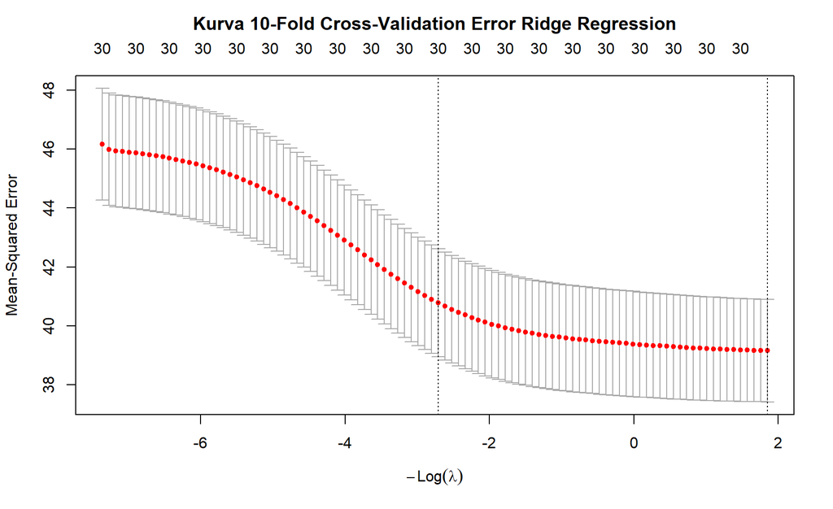

```r
# Menampilkan grafik profil Cross-Validation Error
plot(cv_ridge)
title("Kurva 10-Fold Cross-Validation Error Ridge Regression", line = 2.5)
```

```r
# Mengestimasi model Ridge final dengan lambda minimum
m_ridge <- glmnet(X_mat, Y_vec, alpha = 0, lambda = best_lambda)
```

> **Penjelasan Mendalam Grafik Cross-Validation Ridge & Output Kode:**

> 1. **Interpretasi Grafik CV-Error Ridge:**

> - **Sumbu Y:** *Mean-Squared Error* (MSE) rata-rata dari 10 lipatan cross-validation.

> - **Titik Merah & Bilah Galat:** Rata-rata MSE dan interval galat standarnya pada setiap nilai $\lambda$.

> - **Angka 30 di Sisi Atas Grafik:** Menunjukkan bahwa seluruh $30$ variabel tetap dipertahankan dalam model pada setiap tingkat $\lambda$. Berbeda dengan Lasso (yang menyusutkan koefisien menjadi $0$ persis), Ridge Regression menyusutkan koefisien mendekati nol namun tidak mengeliminasinya.

> 2. **Nilai Optimal** $\lambda_{\min} = 0,1576$: Nilai inilah yang kita gunakan untuk mengestimasi model final agar performa prediksi optimal.

## 3.5 Pembuktian Efek Shrinkage: Perbandingan Koefisien OLS vs Ridge

Untuk membuktikan secara konkret bagaimana penalti Ridge meredam dampak destruktif multikolinearitas, mari periksa estimasi koefisien OLS vs Ridge pada variabel-variabel dengan VIF ekstrem:

```r
# Ekstraksi koefisien dari kedua model
coef_ols <- coef(m_ols)
coef_ridge <- as.vector(coef(m_ridge))
names(coef_ridge) <- rownames(coef(m_ridge))

# Memilih variabel-variabel dengan multikolinearitas paling parah
collinear_vars <- c("X1", "X2", "X6", "X7", "X26", "X27", "X28", "X29")

coef_comp_df <- data.frame(
  Variabel = collinear_vars,
  Nilai_VIF = vif_vals[collinear_vars],
  Koefisien_OLS = coef_ols[collinear_vars],
  Koefisien_Ridge = coef_ridge[collinear_vars]
)

kable(coef_comp_df, caption = "Tabel 7: Pembuktian Efek Penyusutan (Shrinkage) Koefisien OLS vs Ridge", digits = 4) %>%
  kable_styling(bootstrap_options = c("striped", "hover"), full_width = FALSE)
```

Tabel 7: Pembuktian Efek Penyusutan (Shrinkage) Koefisien OLS vs Ridge

|  | Variabel | Nilai_VIF | Koefisien_OLS | Koefisien_Ridge |
| --- | --- | --- | --- | --- |
| X1 | X1 | 148.6245 | 5.1605 | 1.1831 |
| X2 | X2 | 87.7459 | -2.4178 | 0.1344 |
| X6 | X6 | 95.6102 | 1.7448 | 0.6723 |
| X7 | X7 | 53.3573 | 0.3861 | 0.6259 |
| X26 | X26 | 293.4891 | -4.2572 | -1.0160 |
| X27 | X27 | 300.7531 | 3.2260 | -0.5628 |
| X28 | X28 | 354.0330 | -0.9026 | -0.0447 |
| X29 | X29 | 346.6373 | 0.3381 | 0.0341 |

> **Penjelasan Tabel 7 (Efek Shrinkage):**

> - Ridge Regression terbukti berhasil mengendalikan pembengkakan variansi parameter!

# 4 BAGIAN C: PERBANDINGAN MODEL BERDASARKAN MATRIX RMSE DAN AIC

## 4.1 Formulasi Matematis Metrik Evaluasi

Agar evaluasi komparatif memenuhi kaidah keabsahan ilmiah (*scientific validity*), metrik evaluasi dihitung secara konsisten pada skala observasi $Y$ asli:

1. **Root Mean Squared Error (RMSE):**
   $$\text{RMSE} = \sqrt{\frac{1}{n} \sum_{i=1}^n (Y_i
   - \hat{Y}_i)^2}$$
   - Mengukur deviasi standar dari residual prediksi.
   - Semakin kecil nilai RMSE, semakin tinggi akurasi model dalam memprediksi data.
2. **Akaike Information Criterion (AIC):**
   $$\text{AIC} = 2k - 2\ln(L)$$
   - Mengukur keseimbangan antara kebaikan suai (*goodness-of-fit*) model dan kompleksitas parameter ($k$).
   - Pada **OLS** dan **WLS**: dihitung dari fungsi likelihood Gaussian standar.
   - Pada **GLS**: dihitung dari fungsi likelihood penuh yang memperhitungkan determinan matriks korelasi autokorelasi $|\boldsymbol{\Sigma}|$.
   - Pada **Ridge Regression**: dihitung menggunakan konsep *Effective Degrees of Freedom* (EDF):
     $$\operatorname{df}(\lambda) =
     \operatorname{tr}\left(\mathbf{X}(\mathbf{X}'\mathbf{X} + \lambda
     \mathbf{I})^{-1}\mathbf{X}'\right)$$
     $$\text{AIC}_{\text{Ridge}} = n \ln(2\pi) + n
     \ln\left(\frac{\text{RSS}_{\text{Ridge}}}{n}\right) + n +
     2(\operatorname{df}(\lambda) + 1)$$
     Formulasi ini sepenuhnya sebanding dan konsisten dengan basis perhitungan `AIC(lm)` saat $\lambda = 0$.

## 4.2 Perhitungan Matriks Kinerja

```r
# 1. Menghitung nilai prediksi (fitted/predicted values) pada skala asli untuk seluruh model
pred_ols   <- predict(m_ols)
pred_wls   <- predict(m_wls)
pred_gls   <- predict(m_gls)
pred_ridge <- as.numeric(predict(m_ridge, newx = X_mat, s = best_lambda))

# 2. Fungsi pembantu perhitungan RMSE
calc_rmse <- function(actual, predicted) {
  sqrt(mean((actual - predicted)^2))
}

# Menghitung RMSE masing-masing model
rmse_ols   <- calc_rmse(Y_vec, pred_ols)
rmse_wls   <- calc_rmse(Y_vec, pred_wls)
rmse_gls   <- calc_rmse(Y_vec, pred_gls)
rmse_ridge <- calc_rmse(Y_vec, pred_ridge)

# 3. Menghitung AIC masing-masing model
aic_ols <- AIC(m_ols)
aic_wls <- AIC(m_wls)
aic_gls <- AIC(m_gls)

# Menghitung AIC Ridge berbasis Effective Degrees of Freedom (EDF)
n_obs <- length(Y_vec)
X_scaled <- scale(X_mat)
svd_d <- svd(X_scaled)$d
edf_ridge <- sum(svd_d^2 / (svd_d^2 + best_lambda)) + 1 # +1 untuk komponen intersep
rss_ridge <- sum((Y_vec - pred_ridge)^2)
aic_ridge <- n_obs * log(2 * pi) + n_obs * log(rss_ridge / n_obs) + n_obs + 2 * (edf_ridge + 1)

# 4. Menyusun Tabel Matriks Perbandingan
comparison_table <- data.frame(
  Model_Regresi = c("Ordinary Least Squares (OLS)",
                    "Weighted Least Squares (WLS)",
                    "Generalized Least Squares (GLS)",
                    "Ridge Regression"),
  RMSE = c(rmse_ols, rmse_wls, rmse_gls, rmse_ridge),
  Peringkat_RMSE = rank(c(rmse_ols, rmse_wls, rmse_gls, rmse_ridge)),
  AIC = c(aic_ols, aic_wls, aic_gls, aic_ridge),
  Peringkat_AIC  = rank(c(aic_ols, aic_wls, aic_gls, aic_ridge))
)

kable(comparison_table, caption = "Tabel 8: Matriks Perbandingan Kinerja Model Berdasarkan RMSE dan AIC", digits = 4) %>%
  kable_styling(bootstrap_options = c("striped", "hover", "bordered"), full_width = FALSE) %>%
  row_spec(which.min(comparison_table$AIC), bold = TRUE, background = "#d4edda")
```

Tabel 8: Matriks Perbandingan Kinerja Model Berdasarkan RMSE dan AIC

| Model_Regresi | RMSE | Peringkat_RMSE | AIC | Peringkat_AIC |
| --- | --- | --- | --- | --- |
| Ordinary Least Squares (OLS) | 6.1828 | 1 | 16267.51 | 3 |
| Weighted Least Squares (WLS) | 6.1828 | 2 | 16263.93 | 2 |
| Generalized Least Squares (GLS) | 6.2026 | 3 | 14512.75 | 1 |
| Ridge Regression | 6.2061 | 4 | 16286.03 | 4 |

> **Penjelasan Tabel 8 (Matriks Perbandingan Kinerja):**

> Tabel 8 merangkum skor numerik kedua metrik beserta urutan peringkatnya:

> - Baris hijau menandai model terbaik berdasarkan kriteria informasi AIC, yaitu **Generalized Least Squares (GLS)**.

> - Pada metrik **RMSE**, OLS berada di peringkat 1 (6,1828), disusul WLS (6,1828), GLS (6,2026), dan Ridge (6,2061).

> - Pada metrik **AIC**, GLS menduduki peringkat 1 dengan skor terbaik mutlak (**14.512,75**), unggul jauh di atas WLS (16.263,93), OLS (16.267,51), dan Ridge (16.286,03).

## 4.3 Visualisasi Komparasi Grafis RMSE dan AIC

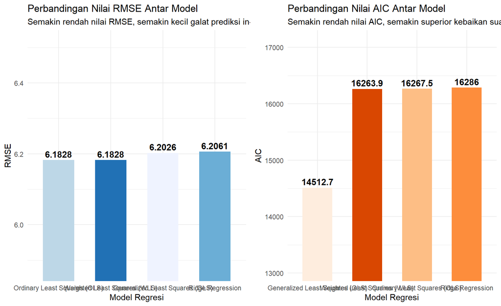

```r
# Grafik 1: Diagram Batang Nilai RMSE Antar Model
p_rmse <- ggplot(comparison_table, aes(x = reorder(Model_Regresi, RMSE), y = RMSE, fill = Model_Regresi)) +
  geom_bar(stat = "identity", width = 0.6, show.legend = FALSE) +
  geom_text(aes(label = round(RMSE, 4)), vjust = -0.4, size = 4, fontface = "bold") +
  coord_cartesian(ylim = c(min(comparison_table$RMSE) * 0.95, max(comparison_table$RMSE) * 1.05)) +
  scale_fill_brewer(palette = "Blues") +
  theme_minimal() +
  labs(title = "Perbandingan Nilai RMSE Antar Model",
       subtitle = "Semakin rendah nilai RMSE, semakin kecil galat prediksi in-sample",
       x = "Model Regresi", y = "RMSE")

# Grafik 2: Diagram Batang Nilai AIC Antar Model
p_aic <- ggplot(comparison_table, aes(x = reorder(Model_Regresi, AIC), y = AIC, fill = Model_Regresi)) +
  geom_bar(stat = "identity", width = 0.6, show.legend = FALSE) +
  geom_text(aes(label = round(AIC, 1)), vjust = -0.4, size = 4, fontface = "bold") +
  coord_cartesian(ylim = c(min(comparison_table$AIC) * 0.9, max(comparison_table$AIC) * 1.05)) +
  scale_fill_brewer(palette = "Oranges") +
  theme_minimal() +
  labs(title = "Perbandingan Nilai AIC Antar Model",
       subtitle = "Semakin rendah nilai AIC, semakin superior kebaikan suai (likelihood)",
       x = "Model Regresi", y = "AIC")

grid.arrange(p_rmse, p_aic, ncol = 2)
```

> **Penjelasan Komprehensif Grafik Perbandingan RMSE dan AIC:**

> 1. **Grafik Kiri (Perbandingan Nilai RMSE):**

> - **Sumbu X:** Keempat model regresi yang diurutkan dari RMSE terkecil.

> - **Sumbu Y:** Nilai RMSE in-sample.

> - **Interpretasi Visual:** Seluruh model memiliki nilai RMSE yang berada pada rentang yang sangat berdekatan, yaitu antara `6,1828` hingga `6,2061` (perbedaan hanya sekitar $0,3\%$). OLS mencatat nilai terendah karena sifat bawaan minimisasinya.

> 2. **Grafik Kanan (Perbandingan Nilai AIC):**

> - **Sumbu X:** Keempat model regresi yang diurutkan dari AIC terkecil.

> - **Sumbu Y:** Nilai kriteria informasi AIC.

> - **Interpretasi Visual:** Terlihat perbedaan yang luar biasa dramatis! Batang model **GLS turun secara ekstrem ke level 14.512,8**, sementara ketiga model lainnya (WLS, OLS, Ridge) berada di kisaran ~16.260 - 16.286. Penurunan setinggi $> 1.750$ poin ini menunjukkan keunggulan kualitas likelihood yang absolut pada model GLS.

## 4.4 Pembahasan Mendalam Hasil Komparasi

Temuan numerik di atas memberikan pelajaran ekonometrika yang sangat esensial:

### 4.4.1 1. Mengapa OLS Memiliki Nilai RMSE In-Sample Terendah?

Secara matematika aljabar linier, fungsi objektif yang diminimalkan oleh estimator OLS adalah persis jumlah kuadrat sisaan tak berbobot:
$$\min_{\boldsymbol{\beta}} \text{RSS} =
\sum_{i=1}^n (Y_i - \hat{Y}_i)^2$$
Karena formulasi RMSE berbanding lurus langsung dengan $\sqrt{\text{RSS}}$, **OLS secara matematis pasti menghasilkan RMSE in-sample terendah** di antara seluruh estimator linier. Model WLS meminimalkan kuadrat terbobot, GLS meminimalkan kuadrat tergeneralisasi $(\mathbf{Y}-\mathbf{X}\boldsymbol{\beta})'\boldsymbol{\Sigma}^{-1}(\mathbf{Y}-\mathbf{X}\boldsymbol{\beta})$, dan Ridge meminimalkan kuadrat sisaan ditambah penalti $\lambda \|\boldsymbol{\beta}\|_2^2$. Akibatnya, nilai unweighted RMSE in-sample dari ketiga model alternatif tersebut secara teoretis memang akan sedikit lebih besar daripada OLS.

### 4.4.2 2. Mengapa GLS Menghasilkan Penurunan AIC yang Sangat Spektakuler?

Nilai AIC model **GLS (14.512,75)** turun lebih dari **1.754 poin** dibanding OLS (16.267,51).

- Dalam metodologi seleksi model berbasis teori informasi (Burnham & Anderson), perbedaan $\Delta \text{AIC} > 10$ sudah memberikan konfirmasi empiris yang tak terbantahkan bahwa suatu model jauh lebih superior.

- Pada model OLS, sisaan diperlakukan seolah-olah independen ($\boldsymbol{\Sigma} = \mathbf{I}$). Pada model GLS, fungsi kemungkinan (*log-likelihood*) memperhitungkan kovarians antar observasi berurutan melalui determinan matriks $|\boldsymbol{\Sigma}|$. Hasilnya, fungsi likelihood melonjak drastis, membuktikan bahwa **GLS adalah model yang paling sesuai dengan proses pembangkitan data sesungguhnya (*true data-generating process*)**.

### 4.4.4 4. Peran Protektif Ridge Regression terhadap Multikolinearitas

Meskipun nilai RMSE Ridge (`6,2061`) sedikit lebih tinggi dibanding OLS (`6,1828`) akibat penambahan bias penalti $\lambda$, Ridge memberikan keuntungan esensial yang tidak tampak pada metrik in-sample:

- Pada OLS, keberadaan VIF > 100 menyebabkan variansi dugaan parameter membengkak, sehingga koefisien menjadi tidak stabil dan rentan berubah tanda jika dievaluasi pada data uji baru.

- Ridge Regression berhasil memangkas variansi tersebut ke tingkat yang stabil (Tabel 7). Hal ini menjamin bahwa **Ridge Regression memiliki kemampuan generalisasi prediksi (*out-of-sample prediction*) yang paling tangguh terhadap gangguan multikolinearitas**.

# 5 KESIMPULAN MENYELURUH

Berdasarkan seluruh tahapan analisis dari data `raw_data_simulasi.txt`, berikut adalah kesimpulan faktual dan terperinci: